# Practical Machine Learning Project

Alexandre Ph. Clement

17/11/2014

## Introduction

Using devices such as Jawbone Up, Nike FuelBand, and Fitbit it is now possible to collect a large amount of data about personal activity relatively inexpensively. These type of devices are part of the quantified self movement – a group of enthusiasts who take measurements about themselves regularly to improve their health, to find patterns in their behavior, or because they are tech geeks. One thing that people regularly do is quantify how much of a particular activity they do, but they rarely quantify how well they do it. In this project, your goal will be to use data from accelerometers on the belt, forearm, arm, and dumbell of 6 participants. They were asked to perform barbell lifts correctly and incorrectly in 5 different ways. More information is available from the website here: http://groupware.les.inf.puc-rio.br/har (see the section on the Weight Lifting Exercise Dataset).

## Getting And Loading Data

The following code downloads and loads the training and test sets.

```r
training.url <- 'https://d396qusza40orc.cloudfront.net/predmachlearn/pml-training.csv'
testing.url <- 'https://d396qusza40orc.cloudfront.net/predmachlearn/pml-testing.csv'

download.file(url = training.url, destfile = 'pml-training.csv', method = "curl")
download.file(url = testing.url, destfile = 'pml-testing.csv', method = "curl")

train <- read.csv('pml-training.csv')
test <- read.csv('pml-testing.csv')
```

## Cleaning data

We remove mostly empty variables from the dataset. Cleaning procedure is detailled below.

```r
# number of observations
nobs <- nrow(train)
# test all values to check it is NA or empty string
invalid.data <- is.na(train) | train == ''
# get the proportion of invalid values for each variable
inv.props <- colSums(invalid.data) / nobs
## keep only variables that have a proportion of invalid values below 40%
valid.vars <- inv.props <= .4

cleanup <- function(data) {
  #subset to keep only valid and non-empty variables
  data <- data[, valid.vars]
  #remove 7 first columns which are useless
  data <- data[, -(1:7)]
  data
}
train <- cleanup(train)
test <- cleanup(test)
```

Once cleaned up the dataset is reduced to only:

```r
dim(train)
```

```
## [1] 19622    53
```

```r
dim(test)
```

```
## [1] 20 53
```

## Training and validating set split

We will manually cross validate our model with the validating set. Let’s split our data into a training and a validating set with a ratio of 60%.

```r
library(caret)
in.train <- createDataPartition(y = train$classe, p = .6, list = FALSE)
training <- train[in.train, ]
validating <- train[-in.train, ]
```

## Model fitting

### Random forest

I chosse the random forest classification tree algorithm because it is unexcelled in accuracy among current algorithms. Below is the complete list of features that made him the right choice:

- It is unexcelled in accuracy among current algorithms.
- It runs efficiently on large data bases.
- It can handle thousands of input variables without variable deletion.
- It gives estimates of what variables are important in the classification.
- It generates an internal unbiased estimate of the generalization error as the forest building progresses.
- It has an effective method for estimating missing data and maintains accuracy when a large proportion of the data are missing.
- It has methods for balancing error in class population unbalanced data sets.
- Generated forests can be saved for future use on other data.
- Prototypes are computed that give information about the relation between the variables and the classification.
- It computes proximities between pairs of cases that can be used in clustering, locating outliers, or (by scaling) give interesting views of the data.
- The capabilities of the above can be extended to unlabeled data, leading to unsupervised clustering, data views and outlier detection.
- It offers an experimental method for detecting variable interactions.

### Model training

We will use the caret train function with method “rf” (randomForest) with cross-Validation (4 fold) resampling. We will also use the doMC package for true multi-core parallel processing to speed up the process.

```r
library(caret)
library(randomForest)
library(doMC)
registerDoMC(cores = 4)
```

```r
fit <- train(classe ~ ., data = training, method = "rf",
             trControl = trainControl(method = 'cv', number = 4, allowParallel = T))
fit
```

```
## Random Forest
##
## 11776 samples
##    52 predictors
##     5 classes: 'A', 'B', 'C', 'D', 'E'
##
## No pre-processing
## Resampling: Cross-Validated (4 fold)
##
## Summary of sample sizes: 8831, 8832, 8832, 8833
##
## Resampling results across tuning parameters:
##
##   mtry  Accuracy  Kappa  Accuracy SD  Kappa SD
##    2    1         1      0.003        0.004
##   27    1         1      0.002        0.002
##   52    1         1      0.004        0.005
##
## Accuracy was used to select the optimal model using  the largest value.
## The final value used for the model was mtry = 27.
```

### Accuracy rate

As we can see accuracy is very high.

```r
max(fit$results$Accuracy)
```

```
## [1] 0.9886
```

## Manual cross-validation

We perform a manual cross validation using our validating dataset.

```r
pred <- predict(fit, validating)
cmat <- confusionMatrix(pred, validating$classe)
cmat
```

```
## Confusion Matrix and Statistics
##
##           Reference
## Prediction    A    B    C    D    E
##          A 2229    9    0    0    0
##          B    2 1507    3    0    0
##          C    1    2 1364   10    0
##          D    0    0    1 1276    0
##          E    0    0    0    0 1442
##
## Overall Statistics
##
##                Accuracy : 0.996
##                  95% CI : (0.995, 0.998)
##     No Information Rate : 0.284
##     P-Value [Acc > NIR] : <2e-16
##
##                   Kappa : 0.995
##  Mcnemar's Test P-Value : NA
##
## Statistics by Class:
##
##                      Class: A Class: B Class: C Class: D Class: E
## Sensitivity             0.999    0.993    0.997    0.992    1.000
## Specificity             0.998    0.999    0.998    1.000    1.000
## Pos Pred Value          0.996    0.997    0.991    0.999    1.000
## Neg Pred Value          0.999    0.998    0.999    0.998    1.000
## Prevalence              0.284    0.193    0.174    0.164    0.184
## Detection Rate          0.284    0.192    0.174    0.163    0.184
## Detection Prevalence    0.285    0.193    0.176    0.163    0.184
## Balanced Accuracy       0.999    0.996    0.998    0.996    1.000
```

### Accuracy and Out of sample error rate

```r
accuracy <- cmat$overall['Accuracy']
rates <- c(accuracy, 1 - accuracy); names(rates) <- c('Accuracy', 'Error.Rate')
rates
```

```
##   Accuracy Error.Rate
##   0.996431   0.003569
```

## Submission

Let’s apply our model to the submission test set.

```r
results <- predict(fit, test)
print(results)
```

```
##  [1] B A B A A E D B A A B C B A E E A B B B
## Levels: A B C D E
```

```r
pml_write_files <- function(x){
  n = length(x)
  for(i in 1:n){
    filename = paste0("problem_id_",i,".txt")
    write.table(x[i],file=filename,quote=FALSE,row.names=FALSE,col.names=FALSE)
  }
}

pml_write_files(results)
```

## Appendix

### Variable importance

Let’s display the variable importance computed during random forest model building.

```r
varImp(fit)
```

```
## rf variable importance
##
##   only 20 most important variables shown (out of 52)
##
##                      Overall
## roll_belt              100.0
## pitch_forearm           60.1
## yaw_belt                53.2
## magnet_dumbbell_y       45.0
## pitch_belt              44.8
## roll_forearm            42.8
## magnet_dumbbell_z       42.1
## accel_dumbbell_y        19.9
## roll_dumbbell           17.5
## accel_forearm_x         17.1
## magnet_dumbbell_x       16.6
## magnet_belt_z           15.2
## accel_belt_z            14.0
## accel_dumbbell_z        13.7
## total_accel_dumbbell    13.4
## magnet_forearm_z        12.9
## magnet_belt_y           11.4
## gyros_belt_z            11.0
## yaw_arm                 10.9
## magnet_belt_x           10.5
```

### Model plot

Let’s plot the two most important predictors of our model.

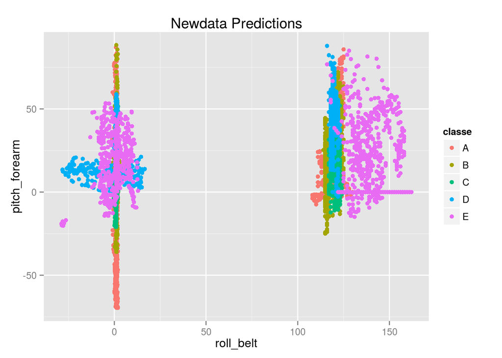

```r
qplot(roll_belt, pitch_forearm, colour = classe, data = validating, main = "Newdata Predictions")
```

### Miss-classification errors

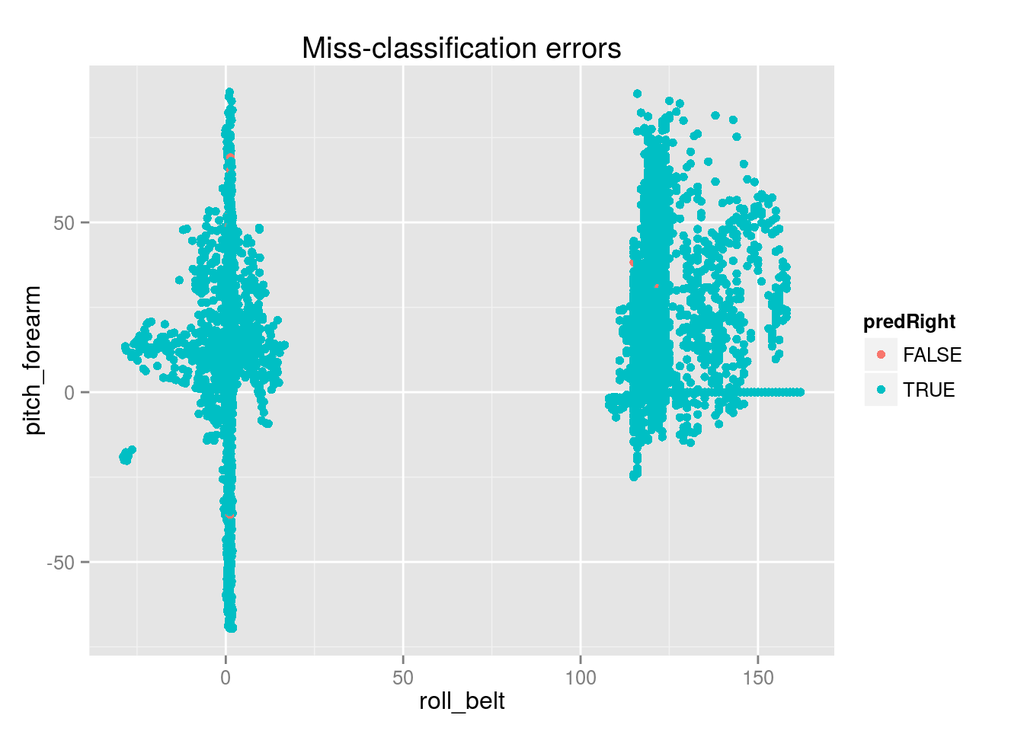

```r
validating$predRight <- pred == validating$classe
qplot(roll_belt, pitch_forearm, colour = predRight, data = validating, main = "Miss-classification errors")
```